# Testing SEACells output

## Introduction

After running SEACells on the data, we want to do some evaluation of how well it might have worked on various samples. This notebook is to pilot what some of the more and less useful visualizations might be, as well as to test running in a Quarto notebook.

## Setup

```python
import pathlib
import pickle
import warnings

# quiet some annoying warnings
warnings.simplefilter(action="ignore", category=FutureWarning)
```

```python
import git
import matplotlib.pyplot as plt
import scanpy as sc
import seaborn as sns
import SEACells
```

```python
project_id = "SCPCP000001"
sample_id = "SCPCS000001"
library_id = "SCPCL000001"
```

### Path definitions

```python
root_dir = pathlib.Path(git.Repo(".", search_parent_directories=True).working_dir)
data_dir = root_dir / "data" / "current"
base_dir = root_dir / "analyses" / "metacells"
results_dir = base_dir / "results" / project_id / sample_id

# these files were created by the `scripts/run-seacells.py` script
sc_anndata_file = results_dir / f"{library_id}_seacells.h5ad"
sc_model_file = results_dir / f"{library_id}_seacells_model.pkl"
```

### Load SEACells results

```python
# the updated AnnData file
sc_ad = sc.read(sc_anndata_file)
# the SEACells model object
with open(sc_model_file, "rb") as f:
    sc_model = pickle.load(f)
```

## Visualizations

### Kernel matrix

The first visualization we will look at is the kernel matrix. This should show a strong block-diagonal structure.

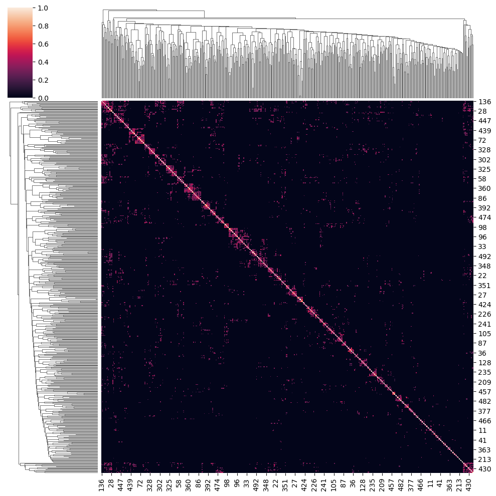

```python
sns.clustermap(sc_model.kernel_matrix.toarray()[:500, :500])
plt.show()
```

### Model fitting

We can look at where SEACells started with the metacells as plotted on the UMAP grid, and how the model converged.

First, where it started:

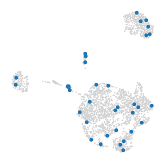

```python
SEACells.plot.plot_initialization(sc_ad, sc_model)
```

Now, how the convergence went:

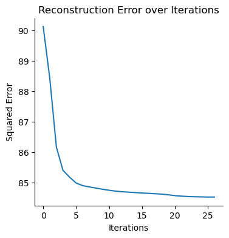

```python
sc_model.plot_convergence()
```

Finally, we can see where the metacells ended up on the UMAP grid:

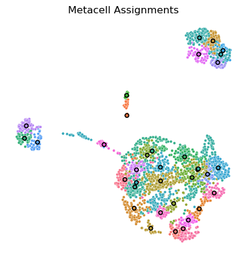

```python
SEACells.plot.plot_2D(sc_ad, key="X_umap", colour_metacells=True)
```

We can also plot how many cells were assigned to each metacell:

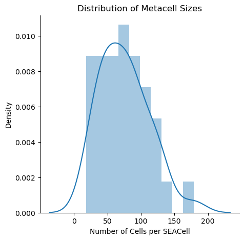

| SEACell | size |
| --- | --- |
| SEACell-0 | 103 |
| SEACell-1 | 46 |
| SEACell-2 | 25 |
| SEACell-3 | 40 |
| SEACell-4 | 85 |
| SEACell-5 | 83 |
| SEACell-6 | 29 |
| SEACell-7 | 179 |
| SEACell-8 | 82 |
| SEACell-9 | 43 |
| SEACell-10 | 80 |
| SEACell-11 | 92 |
| SEACell-12 | 18 |
| SEACell-13 | 124 |
| SEACell-14 | 56 |
| SEACell-15 | 126 |
| SEACell-16 | 126 |
| SEACell-17 | 100 |
| SEACell-18 | 114 |
| SEACell-19 | 57 |
| SEACell-20 | 113 |
| SEACell-21 | 77 |
| SEACell-22 | 136 |
| SEACell-23 | 29 |
| SEACell-24 | 44 |
| SEACell-25 | 51 |
| SEACell-26 | 57 |
| SEACell-27 | 69 |
| SEACell-28 | 86 |
| SEACell-29 | 67 |
| SEACell-30 | 59 |
| SEACell-31 | 32 |
| SEACell-32 | 44 |
| SEACell-33 | 70 |
| SEACell-34 | 90 |

```python
SEACells.plot.plot_SEACell_sizes(sc_ad, bins=10)
```

### Cell type purity

The first real measure of how well SEACells worked may be to look at the cell type purity of the metacells. We will use the cell types as assigned by singleR to do this.

If SEACells is working well, we should expect lots of high values here, indicating that most of the cells that contribute to a metacell were from the same initial cell type.

```python
purity = SEACells.evaluate.compute_celltype_purity(sc_ad, "singler_celltype_ontology")
plt.show()
```

[output not shown]